# Overview

Dataset info

| Number of variables | 13 |
| --- | --- |
| Number of observations | 39116 |
| Missing cells | 8002 (1.6%) |
| Duplicate rows | 0 (0.0%) |
| Total size in memory | 3.9 MiB |
| Average record size in memory | 104.0 B |

Variables types

| Numeric | 10 |
| --- | --- |
| Categorical | 3 |
| Boolean | 0 |
| Date | 0 |
| URL | 0 |
| Text (Unique) | 0 |
| Rejected | 0 |
| Unsupported | 0 |

Warnings

| `availability_365` has 14102 (36.1%) zeros | Zeros |
| --- | --- |
| `minimum_nights` is highly skewed (γ1 = 22.76235718) | Skewed |
| `neighbourhood` has a high cardinality: 221 distinct values | Warning |
| `number_of_reviews` has 8002 (20.5%) zeros | Zeros |
| `reviews_per_month` has 8002 (20.5%) missing values | Missing |

# Variables

availability_365  
Numeric

| Distinct count | 366 |
| --- | --- |
| Unique (%) | 0.9% |
| Missing (%) | 0.0% |
| Missing (n) | 0 |
| Infinite (%) | 0.0% |
| Infinite (n) | 0 |

| Mean | 112.1431639 |
| --- | --- |
| Minimum | 0 |
| Maximum | 365 |
| Zeros (%) | 36.1% |

[figure not shown]

Toggle details

**Statistics**

Quantile statistics

| Minimum | 0 |
| --- | --- |
| 5-th percentile | 0 |
| Q1 | 0 |
| Median | 44 |
| Q3 | 224 |
| 95-th percentile | 359 |
| Maximum | 365 |
| Range | 365 |
| Interquartile range | 224 |

Descriptive statistics

| Standard deviation | 131.339466 |
| --- | --- |
| Coef of variation | 1.171176748 |
| Kurtosis | -0.9793063767 |
| Mean | 112.1431639 |
| MAD | 115.9385207 |
| Skewness | 0.7725708832 |
| Sum | 4386592 |
| Variance | 17250.05533 |
| Memory size | 305.7 KiB |

**Histogram**

[figure not shown]

**Histogram with fixed size bins** (bins=50)

[figure not shown]

**Histogram with variable size bins** (bins=[ 0. 0.5 1.5 5.5 8.5 ... 357.5 362.5 363.5 364.5 365. ], ["bayesian blocks"](https://ui.adsabs.harvard.edu/abs/2013ApJ...764..167S/abstract) binning strategy used)

**Common values**

| Value | Count | Frequency (%) |  |
| --- | --- | --- | --- |
| 0 | 14102 | 36.1% |  |
| 365 | 1031 | 2.6% |  |
| 364 | 381 | 1.0% |  |
| 1 | 326 | 0.8% |  |
| 89 | 288 | 0.7% |  |
| 5 | 275 | 0.7% |  |
| 3 | 250 | 0.6% |  |
| 179 | 242 | 0.6% |  |
| 90 | 227 | 0.6% |  |
| 2 | 220 | 0.6% |  |
| Other values (356) | 21774 | 55.7% |  |

**Extreme values**

Minimum 5 values

| Value | Count | Frequency (%) |  |
| --- | --- | --- | --- |
| 0 | 14102 | 36.1% |  |
| 1 | 326 | 0.8% |  |
| 2 | 220 | 0.6% |  |
| 3 | 250 | 0.6% |  |
| 4 | 188 | 0.5% |  |

Maximum 5 values

| Value | Count | Frequency (%) |  |
| --- | --- | --- | --- |
| 365 | 1031 | 2.6% |  |
| 364 | 381 | 1.0% |  |
| 363 | 199 | 0.5% |  |
| 362 | 137 | 0.4% |  |
| 361 | 92 | 0.2% |  |

calculated_host_listings_count  
Numeric

| Distinct count | 47 |
| --- | --- |
| Unique (%) | 0.1% |
| Missing (%) | 0.0% |
| Missing (n) | 0 |
| Infinite (%) | 0.0% |
| Infinite (n) | 0 |

| Mean | 7.155179466 |
| --- | --- |
| Minimum | 1 |
| Maximum | 327 |
| Zeros (%) | 0.0% |

[figure not shown]

Toggle details

**Statistics**

Quantile statistics

| Minimum | 1 |
| --- | --- |
| 5-th percentile | 1 |
| Q1 | 1 |
| Median | 1 |
| Q3 | 2 |
| 95-th percentile | 15 |
| Maximum | 327 |
| Range | 326 |
| Interquartile range | 1 |

Descriptive statistics

| Standard deviation | 33.20723092 |
| --- | --- |
| Coef of variation | 4.641006013 |
| Kurtosis | 67.5512843 |
| Mean | 7.155179466 |
| MAD | 10.31531127 |
| Skewness | 7.946112117 |
| Sum | 279882 |
| Variance | 1102.720186 |
| Memory size | 305.7 KiB |

**Histogram**

[figure not shown]

**Histogram with fixed size bins** (bins=47)

[figure not shown]

**Histogram with variable size bins** (bins=[ 1. 1.5 2.5 3.5 4.5 ... 93.5 99.5 112. 279.5 327. ], ["bayesian blocks"](https://ui.adsabs.harvard.edu/abs/2013ApJ...764..167S/abstract) binning strategy used)

**Common values**

| Value | Count | Frequency (%) |  |
| --- | --- | --- | --- |
| 1 | 25865 | 66.1% |  |
| 2 | 5319 | 13.6% |  |
| 3 | 2267 | 5.8% |  |
| 4 | 1156 | 3.0% |  |
| 5 | 689 | 1.8% |  |
| 6 | 451 | 1.2% |  |
| 8 | 341 | 0.9% |  |
| 7 | 320 | 0.8% |  |
| 327 | 274 | 0.7% |  |
| 9 | 199 | 0.5% |  |
| Other values (37) | 2235 | 5.7% |  |

**Extreme values**

Minimum 5 values

| Value | Count | Frequency (%) |  |
| --- | --- | --- | --- |
| 1 | 25865 | 66.1% |  |
| 2 | 5319 | 13.6% |  |
| 3 | 2267 | 5.8% |  |
| 4 | 1156 | 3.0% |  |
| 5 | 689 | 1.8% |  |

Maximum 5 values

[output not shown]

df_index  
Numeric

| Distinct count | 39116 |
| --- | --- |
| Unique (%) | 100.0% |
| Missing (%) | 0.0% |
| Missing (n) | 0 |
| Infinite (%) | 0.0% |
| Infinite (n) | 0 |

| Mean | 24505.35863 |
| --- | --- |
| Minimum | 0 |
| Maximum | 48894 |
| Zeros (%) | < 0.1% |

[figure not shown]

Toggle details

**Statistics**

Quantile statistics

| Minimum | 0 |
| --- | --- |
| 5-th percentile | 2461.75 |
| Q1 | 12336.5 |
| Median | 24538.5 |
| Q3 | 36705.25 |
| 95-th percentile | 46451.25 |
| Maximum | 48894 |
| Range | 48894 |
| Interquartile range | 24368.75 |

Descriptive statistics

| Standard deviation | 14096.80688 |
| --- | --- |
| Coef of variation | 0.5752540535 |
| Kurtosis | -1.19767891 |
| Mean | 24505.35863 |
| MAD | 12207.92008 |
| Skewness | -0.005229429716 |
| Sum | 958551608 |
| Variance | 198719964.3 |
| Memory size | 305.7 KiB |

**Histogram**

[figure not shown]

**Histogram with fixed size bins** (bins=50)

[figure not shown]

**Histogram with variable size bins** (bins=[ 0. 48894.], ["bayesian blocks"](https://ui.adsabs.harvard.edu/abs/2013ApJ...764..167S/abstract) binning strategy used)

**Common values**

| Value | Count | Frequency (%) |  |
| --- | --- | --- | --- |
| 2047 | 1 | < 0.1% |  |
| 46428 | 1 | < 0.1% |  |
| 30052 | 1 | < 0.1% |  |
| 19811 | 1 | < 0.1% |  |
| 17762 | 1 | < 0.1% |  |
| 21856 | 1 | < 0.1% |  |
| 44383 | 1 | < 0.1% |  |
| 42334 | 1 | < 0.1% |  |
| 48477 | 1 | < 0.1% |  |
| 36187 | 1 | < 0.1% |  |
| Other values (39106) | 39106 | > 99.9% |  |

**Extreme values**

Minimum 5 values

| Value | Count | Frequency (%) |  |
| --- | --- | --- | --- |
| 0 | 1 | < 0.1% |  |
| 1 | 1 | < 0.1% |  |
| 3 | 1 | < 0.1% |  |
| 4 | 1 | < 0.1% |  |
| 5 | 1 | < 0.1% |  |

Maximum 5 values

| Value | Count | Frequency (%) |  |
| --- | --- | --- | --- |
| 48894 | 1 | < 0.1% |  |
| 48893 | 1 | < 0.1% |  |
| 48892 | 1 | < 0.1% |  |
| 48891 | 1 | < 0.1% |  |
| 48889 | 1 | < 0.1% |  |

host_id  
Numeric

| Distinct count | 30887 |
| --- | --- |
| Unique (%) | 79.0% |
| Missing (%) | 0.0% |
| Missing (n) | 0 |
| Infinite (%) | 0.0% |
| Infinite (n) | 0 |

| Mean | 68023983.18 |
| --- | --- |
| Minimum | 2438 |
| Maximum | 274321313 |
| Zeros (%) | 0.0% |

[figure not shown]

Toggle details

**Statistics**

Quantile statistics

| Minimum | 2438 |
| --- | --- |
| 5-th percentile | 828641.25 |
| Q1 | 7858210 |
| Median | 31036065 |
| Q3 | 107434423 |
| 95-th percentile | 241889662 |
| Maximum | 274321313 |
| Range | 274318875 |
| Interquartile range | 99576213 |

Descriptive statistics

| Standard deviation | 78892362.57 |
| --- | --- |
| Coef of variation | 1.159772758 |
| Kurtosis | 0.1324471029 |
| Mean | 68023983.18 |
| MAD | 64692632.88 |
| Skewness | 1.19521831 |
| Sum | 2.660826126e+12 |
| Variance | 6.224004872e+15 |
| Memory size | 305.7 KiB |

**Histogram**

[figure not shown]

**Histogram with fixed size bins** (bins=50)

[figure not shown]

**Histogram with variable size bins** (bins=[2.43800000e+03 2.87450000e+03 5.41415000e+04 7.25565000e+04 3.03904000e+05 ... 2.66832324e+08 2.68114272e+08 2.68149993e+08 2.71412902e+08 2.74321313e+08], ["bayesian blocks"](https://ui.adsabs.harvard.edu/abs/2013ApJ...764..167S/abstract) binning strategy used)

**Common values**

| Value | Count | Frequency (%) |  |
| --- | --- | --- | --- |
| 219517861 | 274 | 0.7% |  |
| 107434423 | 175 | 0.4% |  |
| 30283594 | 96 | 0.2% |  |
| 137358866 | 83 | 0.2% |  |
| 16098958 | 80 | 0.2% |  |
| 12243051 | 71 | 0.2% |  |
| 61391963 | 70 | 0.2% |  |
| 22541573 | 67 | 0.2% |  |
| 200380610 | 51 | 0.1% |  |
| 7503643 | 43 | 0.1% |  |
| Other values (30877) | 38106 | 97.4% |  |

**Extreme values**

Minimum 5 values

| Value | Count | Frequency (%) |  |
| --- | --- | --- | --- |
| 2438 | 1 | < 0.1% |  |
| 2571 | 1 | < 0.1% |  |
| 2787 | 6 | < 0.1% |  |
| 2845 | 2 | < 0.1% |  |
| 2868 | 1 | < 0.1% |  |

Maximum 5 values

| Value | Count | Frequency (%) |  |
| --- | --- | --- | --- |
| 274321313 | 1 | < 0.1% |  |
| 274311461 | 1 | < 0.1% |  |
| 274307600 | 1 | < 0.1% |  |
| 274298453 | 1 | < 0.1% |  |
| 274273284 | 1 | < 0.1% |  |

latitude  
Numeric

| Distinct count | 17395 |
| --- | --- |
| Unique (%) | 44.5% |
| Missing (%) | 0.0% |
| Missing (n) | 0 |
| Infinite (%) | 0.0% |
| Infinite (n) | 0 |

| Mean | 40.72884925 |
| --- | --- |
| Minimum | 40.49979 |
| Maximum | 40.91306 |
| Zeros (%) | 0.0% |

[figure not shown]

Toggle details

**Statistics**

Quantile statistics

| Minimum | 40.49979 |
| --- | --- |
| 5-th percentile | 40.6458 |
| Q1 | 40.6901475 |
| Median | 40.72292 |
| Q3 | 40.76299 |
| 95-th percentile | 40.82557 |
| Maximum | 40.91306 |
| Range | 0.41327 |
| Interquartile range | 0.0728425 |

Descriptive statistics

| Standard deviation | 0.05451629506 |
| --- | --- |
| Coef of variation | 0.001338517932 |
| Kurtosis | 0.1680149157 |
| Mean | 40.72884925 |
| MAD | 0.04319307247 |
| Skewness | 0.2376679023 |
| Sum | 1593149.667 |
| Variance | 0.002972026427 |
| Memory size | 305.7 KiB |

**Histogram**

[figure not shown]

**Histogram with fixed size bins** (bins=50)

[figure not shown]

**Histogram with variable size bins** (bins=[40.49979 40.538775 40.574555 40.628285 40.632635 ... 40.86645 40.869605 40.888805 40.898715 40.91306 ], ["bayesian blocks"](https://ui.adsabs.harvard.edu/abs/2013ApJ...764..167S/abstract) binning strategy used)

**Common values**

| Value | Count | Frequency (%) |  |
| --- | --- | --- | --- |
| 40.71813 | 16 | < 0.1% |  |
| 40.68444 | 12 | < 0.1% |  |
| 40.68537 | 11 | < 0.1% |  |
| 40.76106 | 11 | < 0.1% |  |
| 40.71171 | 11 | < 0.1% |  |
| 40.71353 | 11 | < 0.1% |  |
| 40.68589 | 11 | < 0.1% |  |
| 40.76189 | 10 | < 0.1% |  |
| 40.69454 | 10 | < 0.1% |  |
| 40.71216 | 10 | < 0.1% |  |
| Other values (17385) | 39003 | 99.7% |  |

**Extreme values**

Minimum 5 values

| Value | Count | Frequency (%) |  |
| --- | --- | --- | --- |
| 40.49979 | 1 | < 0.1% |  |
| 40.50641 | 1 | < 0.1% |  |
| 40.50708 | 1 | < 0.1% |  |
| 40.50868 | 1 | < 0.1% |  |
| 40.50873 | 1 | < 0.1% |  |

Maximum 5 values

| Value | Count | Frequency (%) |  |
| --- | --- | --- | --- |
| 40.91306 | 1 | < 0.1% |  |
| 40.91234 | 1 | < 0.1% |  |
| 40.91167 | 1 | < 0.1% |  |
| 40.90734 | 1 | < 0.1% |  |
| 40.90527 | 1 | < 0.1% |  |

longitude  
Numeric

| Distinct count | 13587 |
| --- | --- |
| Unique (%) | 34.7% |
| Missing (%) | 0.0% |
| Missing (n) | 0 |
| Infinite (%) | 0.0% |
| Infinite (n) | 0 |

| Mean | -73.95232958 |
| --- | --- |
| Minimum | -74.24442 |
| Maximum | -73.71299 |
| Zeros (%) | 0.0% |

[figure not shown]

Toggle details

**Statistics**

Quantile statistics

| Minimum | -74.24442 |
| --- | --- |
| 5-th percentile | -74.00406 |
| Q1 | -73.98318 |
| Median | -73.95575 |
| Q3 | -73.9363875 |
| 95-th percentile | -73.865825 |
| Maximum | -73.71299 |
| Range | 0.53143 |
| Interquartile range | 0.0467925 |

Descriptive statistics

| Standard deviation | 0.04612648513 |
| --- | --- |
| Coef of variation | -0.0006237326855 |
| Kurtosis | 5.000414638 |
| Mean | -73.95232958 |
| MAD | 0.03162949314 |
| Skewness | 1.265189383 |
| Sum | -2892719.324 |
| Variance | 0.00212765263 |
| Memory size | 305.7 KiB |

**Histogram**

[figure not shown]

**Histogram with fixed size bins** (bins=50)

[figure not shown]

**Histogram with variable size bins** (bins=[-74.24442 -74.17334 -74.095225 -74.08721 -74.07721 ... -73.828615 -73.81234 -73.76245 -73.727355 -73.71299 ], ["bayesian blocks"](https://ui.adsabs.harvard.edu/abs/2013ApJ...764..167S/abstract) binning strategy used)

**Common values**

| Value | Count | Frequency (%) |  |
| --- | --- | --- | --- |
| -73.94791 | 15 | < 0.1% |  |
| -73.98589 | 14 | < 0.1% |  |
| -73.95427 | 14 | < 0.1% |  |
| -73.94965 | 13 | < 0.1% |  |
| -73.95669 | 13 | < 0.1% |  |
| -73.98668 | 13 | < 0.1% |  |
| -73.95405 | 13 | < 0.1% |  |
| -73.95489 | 13 | < 0.1% |  |
| -73.95332 | 13 | < 0.1% |  |
| -73.95732 | 13 | < 0.1% |  |
| Other values (13577) | 38982 | 99.7% |  |

**Extreme values**

Minimum 5 values

| Value | Count | Frequency (%) |  |
| --- | --- | --- | --- |
| -74.24442 | 1 | < 0.1% |  |
| -74.24285 | 1 | < 0.1% |  |
| -74.24084 | 1 | < 0.1% |  |
| -74.23986 | 1 | < 0.1% |  |
| -74.23914 | 1 | < 0.1% |  |

Maximum 5 values

| Value | Count | Frequency (%) |  |
| --- | --- | --- | --- |
| -73.71299 | 1 | < 0.1% |  |
| -73.7169 | 1 | < 0.1% |  |
| -73.71795 | 1 | < 0.1% |  |
| -73.71829 | 1 | < 0.1% |  |
| -73.72173 | 1 | < 0.1% |  |

minimum_nights  
Numeric

| Distinct count | 102 |
| --- | --- |
| Unique (%) | 0.3% |
| Missing (%) | 0.0% |
| Missing (n) | 0 |
| Infinite (%) | 0.0% |
| Infinite (n) | 0 |

| Mean | 6.950480622 |
| --- | --- |
| Minimum | 1 |
| Maximum | 1250 |
| Zeros (%) | 0.0% |

[figure not shown]

Toggle details

**Statistics**

Quantile statistics

| Minimum | 1 |
| --- | --- |
| 5-th percentile | 1 |
| Q1 | 1 |
| Median | 2 |
| Q3 | 5 |
| 95-th percentile | 30 |
| Maximum | 1250 |
| Range | 1249 |
| Interquartile range | 4 |

Descriptive statistics

| Standard deviation | 20.29924355 |
| --- | --- |
| Coef of variation | 2.920552499 |
| Kurtosis | 928.9207564 |
| Mean | 6.950480622 |
| MAD | 7.444913705 |
| Skewness | 22.76235718 |
| Sum | 271875 |
| Variance | 412.0592888 |
| Memory size | 305.7 KiB |

**Histogram**

[figure not shown]

**Histogram with fixed size bins** (bins=50)

[figure not shown]

**Histogram with variable size bins** (bins=[1.000e+00 1.500e+00 2.500e+00 3.500e+00 4.500e+00 ... 1.805e+02 2.050e+02 3.645e+02 3.655e+02 1.250e+03], ["bayesian blocks"](https://ui.adsabs.harvard.edu/abs/2013ApJ...764..167S/abstract) binning strategy used)

**Common values**

| Value | Count | Frequency (%) |  |
| --- | --- | --- | --- |
| 1 | 10171 | 26.0% |  |
| 2 | 9415 | 24.1% |  |
| 3 | 6422 | 16.4% |  |
| 30 | 2980 | 7.6% |  |
| 4 | 2653 | 6.8% |  |
| 5 | 2417 | 6.2% |  |
| 7 | 1638 | 4.2% |  |
| 6 | 594 | 1.5% |  |
| 14 | 441 | 1.1% |  |
| 10 | 385 | 1.0% |  |
| Other values (92) | 2000 | 5.1% |  |

**Extreme values**

Minimum 5 values

| Value | Count | Frequency (%) |  |
| --- | --- | --- | --- |
| 1 | 10171 | 26.0% |  |
| 2 | 9415 | 24.1% |  |
| 3 | 6422 | 16.4% |  |
| 4 | 2653 | 6.8% |  |
| 5 | 2417 | 6.2% |  |

Maximum 5 values

| Value | Count | Frequency (%) |  |
| --- | --- | --- | --- |
| 1250 | 1 | < 0.1% |  |
| 1000 | 1 | < 0.1% |  |
| 999 | 2 | < 0.1% |  |
| 500 | 4 | < 0.1% |  |
| 480 | 1 | < 0.1% |  |

neighbourhood  
Categorical

| Distinct count | 221 |
| --- | --- |
| Unique (%) | 0.6% |
| Missing (%) | 0.0% |
| Missing (n) | 0 |

| Williamsburg | 3167 |
| --- | --- |
| Bedford-Stuyvesant | 3000 |
| Harlem | 2131 |
| Other values (218) | 30818 |

Toggle details

**Common values**

| Value | Count | Frequency (%) |  |
| --- | --- | --- | --- |
| Williamsburg | 3167 | 8.1% |  |
| Bedford-Stuyvesant | 3000 | 7.7% |  |
| Harlem | 2131 | 5.4% |  |
| Bushwick | 1991 | 5.1% |  |
| Hell's Kitchen | 1581 | 4.0% |  |
| Upper West Side | 1545 | 3.9% |  |
| East Village | 1473 | 3.8% |  |
| Upper East Side | 1443 | 3.7% |  |
| Midtown | 1251 | 3.2% |  |
| Crown Heights | 1230 | 3.1% |  |
| Other values (211) | 20304 | 51.9% |  |

**Composition**

| Max length | 26 |
| --- | --- |
| Mean length | 11.88158298 |
| Min length | 4 |
| Contains chars | True |
| Contains digits | False |
| Contains spaces | True |
| Contains non-words | True |

neighbourhood_group  
Categorical

| Distinct count | 5 |
| --- | --- |
| Unique (%) | < 0.1% |
| Missing (%) | 0.0% |
| Missing (n) | 0 |

| Manhattan | 17332 |
| --- | --- |
| Brooklyn | 16089 |
| Queens | 4515 |
| Other values (2) | 1180 |

Toggle details

**Common values**

| Value | Count | Frequency (%) |  |
| --- | --- | --- | --- |
| Manhattan | 17332 | 44.3% |  |
| Brooklyn | 16089 | 41.1% |  |
| Queens | 4515 | 11.5% |  |
| Bronx | 874 | 2.2% |  |
| Staten Island | 306 | 0.8% |  |

**Composition**

| Max length | 13 |
| --- | --- |
| Mean length | 8.18432355 |
| Min length | 5 |
| Contains chars | True |
| Contains digits | False |
| Contains spaces | True |
| Contains non-words | True |

number_of_reviews  
Numeric

| Distinct count | 371 |
| --- | --- |
| Unique (%) | 0.9% |
| Missing (%) | 0.0% |
| Missing (n) | 0 |
| Infinite (%) | 0.0% |
| Infinite (n) | 0 |

| Mean | 22.98414971 |
| --- | --- |
| Minimum | 0 |
| Maximum | 629 |
| Zeros (%) | 20.5% |

[figure not shown]

Toggle details

**Statistics**

Quantile statistics

| Minimum | 0 |
| --- | --- |
| 5-th percentile | 0 |
| Q1 | 1 |
| Median | 5 |
| Q3 | 23 |
| 95-th percentile | 113 |
| Maximum | 629 |
| Range | 629 |
| Interquartile range | 22 |

Descriptive statistics

| Standard deviation | 43.75513722 |
| --- | --- |
| Coef of variation | 1.903709198 |
| Kurtosis | 18.78954192 |
| Mean | 22.98414971 |
| MAD | 27.17718458 |
| Skewness | 3.634092479 |
| Sum | 899048 |
| Variance | 1914.512033 |
| Memory size | 305.7 KiB |

**Histogram**

[figure not shown]

**Histogram with fixed size bins** (bins=50)

[figure not shown]

**Histogram with variable size bins** (bins=[0.000e+00 5.000e-01 1.500e+00 2.500e+00 3.500e+00 ... 2.335e+02 2.980e+02 3.615e+02 4.625e+02 6.290e+02], ["bayesian blocks"](https://ui.adsabs.harvard.edu/abs/2013ApJ...764..167S/abstract) binning strategy used)

**Common values**

| Value | Count | Frequency (%) |  |
| --- | --- | --- | --- |
| 0 | 8002 | 20.5% |  |
| 1 | 4240 | 10.8% |  |
| 2 | 2747 | 7.0% |  |
| 3 | 2032 | 5.2% |  |
| 4 | 1602 | 4.1% |  |
| 5 | 1287 | 3.3% |  |
| 6 | 1094 | 2.8% |  |
| 7 | 960 | 2.5% |  |
| 8 | 921 | 2.4% |  |
| 9 | 786 | 2.0% |  |
| Other values (361) | 15445 | 39.5% |  |

**Extreme values**

Minimum 5 values

| Value | Count | Frequency (%) |  |
| --- | --- | --- | --- |
| 0 | 8002 | 20.5% |  |
| 1 | 4240 | 10.8% |  |
| 2 | 2747 | 7.0% |  |
| 3 | 2032 | 5.2% |  |
| 4 | 1602 | 4.1% |  |

Maximum 5 values

| Value | Count | Frequency (%) |  |
| --- | --- | --- | --- |
| 629 | 1 | < 0.1% |  |
| 597 | 1 | < 0.1% |  |
| 576 | 1 | < 0.1% |  |
| 540 | 1 | < 0.1% |  |
| 510 | 1 | < 0.1% |  |

price  
Numeric

| Distinct count | 636 |
| --- | --- |
| Unique (%) | 1.6% |
| Missing (%) | 0.0% |
| Missing (n) | 0 |
| Infinite (%) | 0.0% |
| Infinite (n) | 0 |

| Mean | 152.9055885 |
| --- | --- |
| Minimum | 0 |
| Maximum | 10000 |
| Zeros (%) | < 0.1% |

[figure not shown]

Toggle details

**Statistics**

Quantile statistics

| Minimum | 0 |
| --- | --- |
| 5-th percentile | 40 |
| Q1 | 69 |
| Median | 105 |
| Q3 | 175 |
| 95-th percentile | 365 |
| Maximum | 10000 |
| Range | 10000 |
| Interquartile range | 106 |

Descriptive statistics

| Standard deviation | 236.7622497 |
| --- | --- |
| Coef of variation | 1.548421166 |
| Kurtosis | 616.5856319 |
| Mean | 152.9055885 |
| MAD | 92.7491789 |
| Skewness | 19.40426448 |
| Sum | 5981055 |
| Variance | 56056.36289 |
| Memory size | 305.7 KiB |

**Histogram**

[figure not shown]

**Histogram with fixed size bins** (bins=50)

[figure not shown]

**Histogram with variable size bins** (bins=[ 0. 19.5 20.5 24.5 25.5 ... 1999.5 2005. 3100. 9999.5 10000. ], ["bayesian blocks"](https://ui.adsabs.harvard.edu/abs/2013ApJ...764..167S/abstract) binning strategy used)

**Common values**

| Value | Count | Frequency (%) |  |
| --- | --- | --- | --- |
| 100 | 1649 | 4.2% |  |
| 150 | 1637 | 4.2% |  |
| 50 | 1233 | 3.2% |  |
| 60 | 1178 | 3.0% |  |
| 200 | 1136 | 2.9% |  |
| 75 | 1090 | 2.8% |  |
| 80 | 1008 | 2.6% |  |
| 70 | 972 | 2.5% |  |
| 65 | 956 | 2.4% |  |
| 120 | 902 | 2.3% |  |
| Other values (626) | 27355 | 69.9% |  |

**Extreme values**

Minimum 5 values

| Value | Count | Frequency (%) |  |
| --- | --- | --- | --- |
| 0 | 10 | < 0.1% |  |
| 10 | 14 | < 0.1% |  |
| 11 | 3 | < 0.1% |  |
| 12 | 2 | < 0.1% |  |
| 13 | 1 | < 0.1% |  |

Maximum 5 values

| Value | Count | Frequency (%) |  |
| --- | --- | --- | --- |
| 10000 | 3 | < 0.1% |  |
| 9999 | 2 | < 0.1% |  |
| 8500 | 1 | < 0.1% |  |
| 8000 | 1 | < 0.1% |  |
| 7703 | 1 | < 0.1% |  |

reviews_per_month  
Numeric

| Distinct count | 904 |
| --- | --- |
| Unique (%) | 2.3% |
| Missing (%) | 20.5% |
| Missing (n) | 8002 |
| Infinite (%) | 0.0% |
| Infinite (n) | 0 |

| Mean | 1.370286688 |
| --- | --- |
| Minimum | 0.01 |
| Maximum | 58.5 |
| Zeros (%) | 0.0% |

[figure not shown]

Toggle details

**Statistics**

Quantile statistics

| Minimum | 0.01 |
| --- | --- |
| 5-th percentile | 0.04 |
| Q1 | 0.19 |
| Median | 0.71 |
| Q3 | 2.01 |
| 95-th percentile | 4.6435 |
| Maximum | 58.5 |
| Range | 58.49 |
| Interquartile range | 1.82 |

Descriptive statistics

| Standard deviation | 1.685212233 |
| --- | --- |
| Coef of variation | 1.229824568 |
| Kurtosis | 49.2699726 |
| Mean | 1.370286688 |
| MAD | 1.23870986 |
| Skewness | 3.298204832 |
| Sum | 42635.1 |
| Variance | 2.839940271 |
| Memory size | 305.7 KiB |

**Histogram**

[figure not shown]

**Common values**

| Value | Count | Frequency (%) |  |
| --- | --- | --- | --- |
| 0.02 | 736 | 1.9% |  |
| 0.05 | 706 | 1.8% |  |
| 1 | 705 | 1.8% |  |
| 0.03 | 657 | 1.7% |  |
| 0.16 | 553 | 1.4% |  |
| 0.04 | 541 | 1.4% |  |
| 0.08 | 486 | 1.2% |  |
| 0.09 | 483 | 1.2% |  |
| 0.06 | 471 | 1.2% |  |
| 0.11 | 430 | 1.1% |  |
| Other values (893) | 25346 | 64.8% |  |
| (Missing) | 8002 | 20.5% |  |

**Extreme values**

Minimum 5 values

| Value | Count | Frequency (%) |  |
| --- | --- | --- | --- |
| 0.01 | 33 | 0.1% |  |
| 0.02 | 736 | 1.9% |  |
| 0.03 | 657 | 1.7% |  |
| 0.04 | 541 | 1.4% |  |
| 0.05 | 706 | 1.8% |  |

Maximum 5 values

| Value | Count | Frequency (%) |  |
| --- | --- | --- | --- |
| 58.5 | 1 | < 0.1% |  |
| 20.94 | 1 | < 0.1% |  |
| 19.75 | 1 | < 0.1% |  |
| 17.82 | 1 | < 0.1% |  |
| 16.81 | 1 | < 0.1% |  |

room_type  
Categorical

| Distinct count | 3 |
| --- | --- |
| Unique (%) | < 0.1% |
| Missing (%) | 0.0% |
| Missing (n) | 0 |

| Entire home/apt | 20377 |
| --- | --- |
| Private room | 17807 |
| Shared room | 932 |

Toggle details

**Common values**

| Value | Count | Frequency (%) |  |
| --- | --- | --- | --- |
| Entire home/apt | 20377 | 52.1% |  |
| Private room | 17807 | 45.5% |  |
| Shared room | 932 | 2.4% |  |

**Composition**

| Max length | 15 |
| --- | --- |
| Mean length | 13.5389866 |
| Min length | 11 |
| Contains chars | True |
| Contains digits | False |
| Contains spaces | True |
| Contains non-words | True |

# Correlations

**Pearson's r**

[figure not shown]

**Spearman's ρ**

[figure not shown]

**Kendall's τ**

[figure not shown]

**Phik (φk)**

[figure not shown]

**Cramér's V (φc)**

[figure not shown]

**Recoded**

[figure not shown]

# Missing values

**Count**

[figure not shown]

**Matrix**

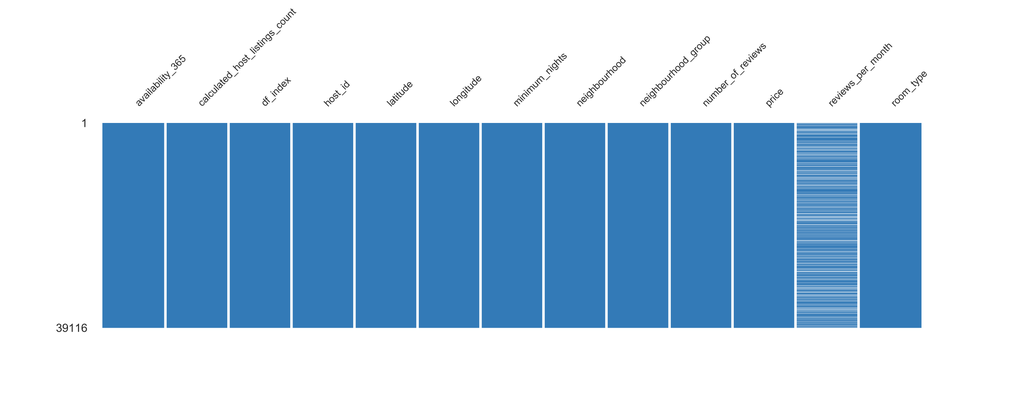

**Dendrogram**

[figure not shown]

# Sample

## First rows

|  | availability_365 | calculated_host_listings_count | df_index | host_id | latitude | longitude | minimum_nights | neighbourhood | neighbourhood_group | number_of_reviews | price | reviews_per_month | room_type |
| --- | --- | --- | --- | --- | --- | --- | --- | --- | --- | --- | --- | --- | --- |
| 0 | 238 | 2 | 21838 | 12302104 | 40.72208 | -73.98109 | 1 | East Village | Manhattan | 116 | 73 | 4.07 | Private room |
| 1 | 317 | 1 | 47539 | 33144953 | 40.72206 | -73.99695 | 4 | Nolita | Manhattan | 0 | 189 | NaN | Entire home/apt |
| 2 | 365 | 3 | 25386 | 1715301 | 40.59546 | -74.06092 | 7 | Fort Wadsworth | Staten Island | 0 | 800 | NaN | Entire home/apt |
| 3 | 345 | 33 | 24173 | 113805886 | 40.77854 | -73.94984 | 31 | Upper East Side | Manhattan | 7 | 265 | 0.30 | Entire home/apt |
| 4 | 0 | 1 | 27875 | 43490965 | 40.69854 | -73.94069 | 2 | Bedford-Stuyvesant | Brooklyn | 4 | 50 | 0.21 | Private room |
| 5 | 0 | 1 | 18483 | 80771146 | 40.69600 | -73.92964 | 3 | Bushwick | Brooklyn | 0 | 65 | NaN | Private room |
| 6 | 249 | 103 | 37255 | 137358866 | 40.74361 | -73.90758 | 30 | Woodside | Queens | 0 | 38 | NaN | Private room |
| 7 | 0 | 1 | 33372 | 8686752 | 40.81857 | -73.94020 | 2 | Harlem | Manhattan | 18 | 100 | 1.45 | Entire home/apt |
| 8 | 345 | 5 | 5206 | 12720552 | 40.70322 | -73.92913 | 1 | Bushwick | Brooklyn | 16 | 110 | 0.32 | Private room |
| 9 | 81 | 1 | 4179 | 3964453 | 40.67795 | -74.00747 | 2 | Red Hook | Brooklyn | 17 | 200 | 1.68 | Entire home/apt |

## Last rows

|  | availability_365 | calculated_host_listings_count | df_index | host_id | latitude | longitude | minimum_nights | neighbourhood | neighbourhood_group | number_of_reviews | price | reviews_per_month | room_type |
| --- | --- | --- | --- | --- | --- | --- | --- | --- | --- | --- | --- | --- | --- |
| 39106 | 0 | 1 | 7751 | 30498160 | 40.80340 | -73.96832 | 1 | Upper West Side | Manhattan | 0 | 40 | NaN | Shared room |
| 39107 | 0 | 1 | 20609 | 16068447 | 40.72363 | -73.97972 | 1 | East Village | Manhattan | 0 | 499 | NaN | Entire home/apt |
| 39108 | 350 | 7 | 32912 | 62533391 | 40.63573 | -74.00552 | 1 | Borough Park | Brooklyn | 1 | 60 | 0.26 | Private room |
| 39109 | 32 | 2 | 21440 | 115057851 | 40.80827 | -73.93813 | 3 | East Harlem | Manhattan | 103 | 100 | 3.61 | Entire home/apt |
| 39110 | 197 | 1 | 7813 | 30836013 | 40.73536 | -73.98393 | 30 | Gramercy | Manhattan | 27 | 209 | 0.53 | Entire home/apt |
| 39111 | 311 | 32 | 43723 | 238321374 | 40.80037 | -73.95940 | 30 | Upper West Side | Manhattan | 0 | 60 | NaN | Private room |
| 39112 | 0 | 1 | 32511 | 8050394 | 40.73308 | -74.00456 | 2 | West Village | Manhattan | 4 | 157 | 0.30 | Entire home/apt |
| 39113 | 8 | 1 | 5192 | 10094431 | 40.71623 | -73.96415 | 1 | Williamsburg | Brooklyn | 78 | 115 | 1.31 | Private room |
| 39114 | 327 | 1 | 12172 | 48943908 | 40.68460 | -73.96536 | 2 | Clinton Hill | Brooklyn | 84 | 330 | 2.03 | Entire home/apt |
| 39115 | 342 | 3 | 33003 | 177314795 | 40.66357 | -73.94509 | 1 | Prospect-Lefferts Gardens | Brooklyn | 59 | 60 | 4.65 | Private room |